# Analyzing Best Picture Winners

### In this notebook, I will answer the following movie-related questions.

- Which genres of film perform better both domestically and internationally
- Which ratings of movies perform best at the box office.
- Do films that win the Best Picture award perform better, on average, at the box office than non-winners

### Before I try to answer these questions, I first need to import the data, examine it, and do some cleaning of the data.

```python
import pandas as pd
import matplotlib.pyplot as plt
import seaborn as sns
import matplotlib.mlab as mlab
import matplotlib
plt.style.use('ggplot')
from matplotlib.pyplot import figure
%matplotlib inline
matplotlib.rcParams['figure.figsize'] = (12,8)
```

```python
df1 = pd.read_csv(r'C:\Users\hunte\Desktop\Movie_Data\movies_gross.csv')
df2 = pd.read_csv(r'C:\Users\hunte\Desktop\Movie_Data\movies_oscars.csv', encoding = "utf-8")
```

```python
df1.head()
```

|  | Unnamed: 0 | Title | Movie Info | Distributor | Release Date | Domestic Sales (in $) | International Sales (in $) | World Sales (in $) | Genre | Movie Runtime | License |
| --- | --- | --- | --- | --- | --- | --- | --- | --- | --- | --- | --- |
| 0 | 0 | Star Wars: Episode VII - The Force Awakens (2015) | As a new threat to the galaxy rises, Rey, a de... | Walt Disney Studios Motion Pictures | December 16, 2015 | 936662225 | 1132859475 | 2069521700 | ['Action', 'Adventure', 'Sci-Fi'] | 2 hr 18 min | PG-13 |
| 1 | 1 | Avengers: Endgame (2019) | After the devastating events of Avengers: Infi... | Walt Disney Studios Motion Pictures | April 24, 2019 | 858373000 | 1939128328 | 2797501328 | ['Action', 'Adventure', 'Drama', 'Sci-Fi'] | 3 hr 1 min | PG-13 |
| 2 | 2 | Avatar (2009) | A paraplegic Marine dispatched to the moon Pan... | Twentieth Century Fox | December 16, 2009 | 760507625 | 2086738578 | 2847246203 | ['Action', 'Adventure', 'Fantasy', 'Sci-Fi'] | 2 hr 42 min | PG-13 |
| 3 | 3 | Black Panther (2018) | T'Challa, heir to the hidden but advanced king... | Walt Disney Studios Motion Pictures | NaN | 700426566 | 647171407 | 1347597973 | ['Action', 'Adventure', 'Sci-Fi'] | 2 hr 14 min | NaN |
| 4 | 4 | Avengers: Infinity War (2018) | The Avengers and their allies must be willing ... | Walt Disney Studios Motion Pictures | NaN | 678815482 | 1369544272 | 2048359754 | ['Action', 'Adventure', 'Sci-Fi'] | 2 hr 29 min | NaN |

```python
df2.head()
```

|  | Title | Winner | Award | Year |
| --- | --- | --- | --- | --- |
| 0 | Nomadland | Y | Picture | 2020 |
| 1 | Judas and the Black Messiah | N | Picture | 2020 |
| 2 | Mank | N | Picture | 2020 |
| 3 | Minari | N | Picture | 2020 |
| 4 | Promising Young Woman | N | Picture | 2020 |

### Filter df2 to only Best Picture winners

```python
df_best_pic = df2[(df2.Winner == 'Y') & (df2.Award == 'Picture')]
```

```python
df_best_pic.head(5)
```

|  | Title | Winner | Award | Year |
| --- | --- | --- | --- | --- |
| 0 | Nomadland | Y | Picture | 2020 |
| 28 | Parasite | Y | Picture | 2019 |
| 57 | Green Book | Y | Picture | 2018 |
| 85 | The Shape of Water | Y | Picture | 2017 |
| 114 | Moonlight | Y | Picture | 2016 |

### Remove the years in parentheses from the Title column in df1 and two drop uneeded columns

```python
df1['Title'] = df1['Title'].str.replace(r'\(\d{4}\)','',regex=True)
df1 = df1.drop(['Movie Info','Distributor'], axis=1)
```

```python
df1.head()
```

|  | Unnamed: 0 | Title | Release Date | Domestic Sales (in $) | International Sales (in $) | World Sales (in $) | Genre | Movie Runtime | License |
| --- | --- | --- | --- | --- | --- | --- | --- | --- | --- |
| 0 | 0 | Star Wars: Episode VII - The Force Awakens | December 16, 2015 | 936662225 | 1132859475 | 2069521700 | ['Action', 'Adventure', 'Sci-Fi'] | 2 hr 18 min | PG-13 |
| 1 | 1 | Avengers: Endgame | April 24, 2019 | 858373000 | 1939128328 | 2797501328 | ['Action', 'Adventure', 'Drama', 'Sci-Fi'] | 3 hr 1 min | PG-13 |
| 2 | 2 | Avatar | December 16, 2009 | 760507625 | 2086738578 | 2847246203 | ['Action', 'Adventure', 'Fantasy', 'Sci-Fi'] | 2 hr 42 min | PG-13 |
| 3 | 3 | Black Panther | NaN | 700426566 | 647171407 | 1347597973 | ['Action', 'Adventure', 'Sci-Fi'] | 2 hr 14 min | NaN |
| 4 | 4 | Avengers: Infinity War | NaN | 678815482 | 1369544272 | 2048359754 | ['Action', 'Adventure', 'Sci-Fi'] | 2 hr 29 min | NaN |

### Remove extra space at end of Title

```python
df1['Title'] = df1['Title'].str.strip()
```

### Add '0 min' to movies that do not have minutes, then convert the runtime to minutes only, and remove 'min'

```python
df1['Movie Runtime'] = df1['Movie Runtime'].str.replace('(\d hr)$', lambda m: m.group(1) + ' 0 min' , regex=True)
df1['Movie Runtime'] = df1['Movie Runtime'].str.replace('(\d+) hr (\d{1,2})', lambda m: str(int(m.group(1)) * 60 + int(m.group(2))), regex=True)
df1['Movie Runtime'] = df1['Movie Runtime'].str.replace(r'min','',regex=True)
df1.head()
```

|  | Unnamed: 0 | Title | Release Date | Domestic Sales (in $) | International Sales (in $) | World Sales (in $) | Genre | Movie Runtime | License |
| --- | --- | --- | --- | --- | --- | --- | --- | --- | --- |
| 0 | 0 | Star Wars: Episode VII - The Force Awakens | December 16, 2015 | 936662225 | 1132859475 | 2069521700 | ['Action', 'Adventure', 'Sci-Fi'] | 138 | PG-13 |
| 1 | 1 | Avengers: Endgame | April 24, 2019 | 858373000 | 1939128328 | 2797501328 | ['Action', 'Adventure', 'Drama', 'Sci-Fi'] | 181 | PG-13 |
| 2 | 2 | Avatar | December 16, 2009 | 760507625 | 2086738578 | 2847246203 | ['Action', 'Adventure', 'Fantasy', 'Sci-Fi'] | 162 | PG-13 |
| 3 | 3 | Black Panther | NaN | 700426566 | 647171407 | 1347597973 | ['Action', 'Adventure', 'Sci-Fi'] | 134 | NaN |
| 4 | 4 | Avengers: Infinity War | NaN | 678815482 | 1369544272 | 2048359754 | ['Action', 'Adventure', 'Sci-Fi'] | 149 | NaN |

### Put all the Best Picture winning titles in a list to use as a filter in the df1 dataframe

```python
the_titles_list = df_best_pic['Title'].tolist()
```

```python
filt = df1['Title'].isin(the_titles_list)

df1_best_picture = df1.loc[filt,]
```

```python
df1_best_picture
```

|  | Unnamed: 0 | Title | Release Date | Domestic Sales (in $) | International Sales (in $) | World Sales (in $) | Genre | Movie Runtime | License |
| --- | --- | --- | --- | --- | --- | --- | --- | --- | --- |
| 6 | 6 | Titanic | December 19, 1997 | 659363944 | 1542283320 | 2201647264 | ['Drama', 'Romance'] | 194 | PG-13 |
| 45 | 45 | The Lord of the Rings: The Return of the King | December 17, 2003 | 377845905 | 768185007 | 1146030912 | ['Action', 'Adventure', 'Drama', 'Fantasy'] | 201 | PG-13 |
| 67 | 67 | Forrest Gump | July 6, 1994 | 330455270 | 347770863 | 678226133 | ['Drama', 'Romance'] | 142 | PG-13 |
| 238 | 238 | Gladiator | May 4, 2000 | 187705427 | 277675375 | 465380802 | ['Action', 'Adventure', 'Drama'] | 155 | R |
| 245 | 245 | Dances with Wolves | November 9, 1990 | 184208848 | 240000000 | 424208848 | ['Adventure', 'Drama', 'Western'] | 181 | NaN |
| 289 | 289 | Rain Man | December 16, 1988 | 172825435 | 182000000 | 354825435 | ['Drama'] | 133 | NaN |
| 297 | 297 | A Beautiful Mind | December 21, 2001 | 170742341 | 146048916 | 316791257 | ['Biography', 'Drama'] | 135 | PG-13 |
| 298 | 298 | Chicago | February 26, 2002 | 170687518 | 136089214 | 306776732 | ['Comedy', 'Crime', 'Musical'] | 113 | PG-13 |
| 409 | 409 | Slumdog Millionaire | November 12, 2008 | 141319928 | 237090614 | 378410542 | ['Drama', 'Romance'] | 120 | R |
| 421 | 421 | The King's Speech | November 26, 2010 | 138797449 | 288576868 | 427374317 | ['Biography', 'Drama', 'History'] | 118 | R |
| 424 | 424 | Platoon | December 19, 1986 | 138530565 | 15067 | 138545632 | ['Drama', 'War'] | 120 | NaN |
| 436 | 436 | Argo | October 11, 2012 | 136025503 | 96300000 | 232325503 | ['Biography', 'Drama', 'Thriller'] | 120 | R |
| 441 | 441 | The Godfather | March 15, 1972 | 134966411 | 111154575 | 246120986 | ['Crime', 'Drama'] | 175 | NaN |
| 457 | 457 | The Departed | October 5, 2006 | 132384315 | 159081058 | 291465373 | ['Crime', 'Drama', 'Thriller'] | 151 | R |
| 465 | 465 | The Silence of the Lambs | February 14, 1991 | 130742922 | 142000000 | 272742922 | ['Crime', 'Drama', 'Horror', 'Thriller'] | 118 | NaN |
| 473 | 473 | American Beauty | September 15, 1999 | 130096601 | 226200000 | 356296601 | ['Drama'] | 122 | R |
| 621 | 621 | Terms of Endearment | November 23, 1983 | 108423489 | 260 | 108423749 | ['Comedy', 'Drama'] | 132 | NaN |
| 696 | 696 | Unforgiven | NaN | 101157447 | 58000000 | 159157447 | ['Drama', 'Western'] | 130 | NaN |
| 712 | 712 | Million Dollar Baby | December 15, 2004 | 100492203 | 116271443 | 216763646 | ['Drama', 'Sport'] | 132 | PG-13 |
| 718 | 718 | Shakespeare in Love | December 11, 1998 | 100317794 | 189000000 | 289317794 | ['Comedy', 'Drama', 'History', 'Romance'] | 123 | R |
| 740 | 740 | Schindler's List | December 15, 1993 | 96898818 | 225262427 | 322161245 | ['Biography', 'Drama', 'History'] | 195 | R |
| 851 | 851 | Green Book | November 16, 2018 | 85080171 | 236672485 | 321752656 | ['Biography', 'Comedy', 'Drama', 'Music'] | 130 | PG-13 |

### Modify and rename the Release Date column to just show the release year, then create a new dataframe organized by Release Year

```python
df1['Release Year'] = df1['Release Date'].str.strip().str[-4:]
df1_release_year = df1.loc[filt,['Title','Release Year','Domestic Sales (in $)','International Sales (in $)','Movie Runtime']].sort_values(by="Release Year").dropna()
df1_release_year
```

|  | Title | Release Year | Domestic Sales (in $) | International Sales (in $) | Movie Runtime |
| --- | --- | --- | --- | --- | --- |
| 441 | The Godfather | 1972 | 134966411 | 111154575 | 175 |
| 621 | Terms of Endearment | 1983 | 108423489 | 260 | 132 |
| 424 | Platoon | 1986 | 138530565 | 15067 | 120 |
| 289 | Rain Man | 1988 | 172825435 | 182000000 | 133 |
| 245 | Dances with Wolves | 1990 | 184208848 | 240000000 | 181 |
| 465 | The Silence of the Lambs | 1991 | 130742922 | 142000000 | 118 |
| 740 | Schindler's List | 1993 | 96898818 | 225262427 | 195 |
| 67 | Forrest Gump | 1994 | 330455270 | 347770863 | 142 |
| 6 | Titanic | 1997 | 659363944 | 1542283320 | 194 |
| 718 | Shakespeare in Love | 1998 | 100317794 | 189000000 | 123 |
| 473 | American Beauty | 1999 | 130096601 | 226200000 | 122 |
| 238 | Gladiator | 2000 | 187705427 | 277675375 | 155 |
| 297 | A Beautiful Mind | 2001 | 170742341 | 146048916 | 135 |
| 298 | Chicago | 2002 | 170687518 | 136089214 | 113 |
| 45 | The Lord of the Rings: The Return of the King | 2003 | 377845905 | 768185007 | 201 |
| 712 | Million Dollar Baby | 2004 | 100492203 | 116271443 | 132 |
| 457 | The Departed | 2006 | 132384315 | 159081058 | 151 |
| 409 | Slumdog Millionaire | 2008 | 141319928 | 237090614 | 120 |
| 421 | The King's Speech | 2010 | 138797449 | 288576868 | 118 |
| 436 | Argo | 2012 | 136025503 | 96300000 | 120 |
| 851 | Green Book | 2018 | 85080171 | 236672485 | 130 |

### Format the data to display with 2 decimal places, add 'thousand-separator' commas, and then view a summary of the movie sales

```python
pd.options.display.float_format = '{:,.2f}'.format
df1_release_year.describe()
```

|  | Domestic Sales (in $) | International Sales (in $) |
| --- | --- | --- |
| count | 21.00 | 21.00 |
| mean | 182,281,469.38 | 269,889,404.38 |
| std | 130,677,071.29 | 330,263,121.17 |
| min | 85,080,171.00 | 260.00 |
| 25% | 130,096,601.00 | 136,089,214.00 |
| 50% | 138,530,565.00 | 189,000,000.00 |
| 75% | 172,825,435.00 | 240,000,000.00 |
| max | 659,363,944.00 | 1,542,283,320.00 |

### Get the top 100 films based on domestic sales, and the top 100 based on international sales, and then compare the two.

```python
filt2 = (df1['Title'].str.len() >  1)
top_domestic = df1.loc[filt2,['Title','Release Year','Domestic Sales (in $)','International Sales (in $)','Genre','Movie Runtime','License']].sort_values(by="Domestic Sales (in $)",ascending=False)
top_domestic = top_domestic.head(100)
top_domestic.head()
```

|  | Title | Release Year | Domestic Sales (in $) | International Sales (in $) | Genre | Movie Runtime | License |
| --- | --- | --- | --- | --- | --- | --- | --- |
| 0 | Star Wars: Episode VII - The Force Awakens | 2015 | 936662225 | 1132859475 | ['Action', 'Adventure', 'Sci-Fi'] | 138 | PG-13 |
| 1 | Avengers: Endgame | 2019 | 858373000 | 1939128328 | ['Action', 'Adventure', 'Drama', 'Sci-Fi'] | 181 | PG-13 |
| 2 | Avatar | 2009 | 760507625 | 2086738578 | ['Action', 'Adventure', 'Fantasy', 'Sci-Fi'] | 162 | PG-13 |
| 3 | Black Panther | NaN | 700426566 | 647171407 | ['Action', 'Adventure', 'Sci-Fi'] | 134 | NaN |
| 4 | Avengers: Infinity War | NaN | 678815482 | 1369544272 | ['Action', 'Adventure', 'Sci-Fi'] | 149 | NaN |

```python
top_domestic.shape
```

```
(100, 7)
```

```python
top_international = df1.loc[filt2,['Title','Release Year','Domestic Sales (in $)','International Sales (in $)','Genre','Movie Runtime','License']].sort_values(by="International Sales (in $)",ascending=False)
top_international = top_international.head(100)
top_international
```

|  | Title | Release Year | Domestic Sales (in $) | International Sales (in $) | Genre | Movie Runtime | License |
| --- | --- | --- | --- | --- | --- | --- | --- |
| 2 | Avatar | 2009 | 760507625 | 2086738578 | ['Action', 'Adventure', 'Fantasy', 'Sci-Fi'] | 162 | PG-13 |
| 1 | Avengers: Endgame | 2019 | 858373000 | 1939128328 | ['Action', 'Adventure', 'Drama', 'Sci-Fi'] | 181 | PG-13 |
| 6 | Titanic | 1997 | 659363944 | 1542283320 | ['Drama', 'Romance'] | 194 | PG-13 |
| 4 | Avengers: Infinity War | NaN | 678815482 | 1369544272 | ['Action', 'Adventure', 'Sci-Fi'] | 149 | NaN |
| 54 | Furious 7 | 2015 | 353007020 | 1162334379 | ['Action', 'Thriller'] | 137 | PG-13 |
| ... | ... | ... | ... | ... | ... | ... | ... |
| 115 | The Amazing Spider-Man | 2012 | 262030663 | 495900000 | ['Action', 'Adventure', 'Sci-Fi'] | 136 | PG-13 |
| 338 | Fantastic Beasts: The Crimes of Grindelwald | 2018 | 159555901 | 495300000 | ['Adventure', 'Family', 'Fantasy'] | 134 | PG-13 |
| 72 | Shrek the Third | 2007 | 322719944 | 490647436 | ['Adventure', 'Animation', 'Comedy', 'Family',... | 93 | PG |
| 44 | Star Wars: Episode III - Revenge of the Sith | 2005 | 380270577 | 488119983 | ['Action', 'Adventure', 'Fantasy', 'Sci-Fi'] | 140 | PG-13 |
| 224 | Mission: Impossible - Rogue Nation | 2015 | 195042377 | 487674259 | ['Action', 'Adventure', 'Thriller'] | 131 | PG-13 |

100 rows × 7 columns

```python
top_international.shape
```

```
(100, 7)
```

### The Genre column for both top_domestic and top_international are lists of values. To compare the two dataframes using that column, I need to break the list apart and get a count of each unique value

```python
import re
from collections import Counter
master_list = []
the_count = 0
for g in top_international['Genre']:
    master_list.append(g)
    the_count = the_count + 1

x = top_international['Genre'].to_list()
the_count = 0

word_set = set()
word_list = []
for c in range(len(master_list)):
    for i in x[c].split(", "):
        y = re.sub("[\[\]]","",i)
        the_count = the_count + 1
        word_set.add(y)
        word_list.append(y)


word_dictionary = {}
for w in word_set:
    d = Counter(word_list)
    word_dictionary[w] = d[w]

# sort the dictionary by values
sorted_temp = sorted(word_dictionary.items(), key=lambda x:x[1],reverse=True)
sorted_word_dictionary = dict(sorted_temp)

#for key, value in sorted_word_dictionary.items() :
 #   print (key)
```

```python
master_list2 = []
the_count2 = 0
for g2 in top_domestic['Genre']:
    master_list2.append(g2)
    the_count2 = the_count2 + 1

x2 = top_domestic['Genre'].to_list()
the_count2 = 0


word_set2 = set()
word_list2 = []
for c2 in range(len(master_list2)):
    for i2 in x2[c2].split(", "):
        y2 = re.sub("[\[\]]","",i2)
        the_count2 = the_count2 + 1
        word_set2.add(y2)
        word_list2.append(y2)


word_dictionary2 = {}
for w2 in word_set2:
    d2 = Counter(word_list2)
    word_dictionary2[w2] = d2[w2]

# sort the dictionary by values
sorted_temp2 = sorted(word_dictionary2.items(), key=lambda x:x[1],reverse=True)
sorted_word_dictionary2 = dict(sorted_temp2)
#print(sorted_word_dictionary2)

#for key, value in sorted_word_dictionary2.items() :
#    print (key)
```

```python
print(sorted_word_dictionary)   # international movies
```

```
{"'Adventure'": 91, "'Action'": 58, "'Fantasy'": 44, "'Sci-Fi'": 41, "'Family'": 36, "'Comedy'": 23, "'Animation'": 22, "'Thriller'": 16, "'Drama'": 15, "'Mystery'": 11, "'Crime'": 9, "'Romance'": 7, "'Musical'": 6, "'Music'": 2, "'Biography'": 1}
```

```python
print(sorted_word_dictionary2)   # domestic movies
```

```
{"'Adventure'": 90, "'Action'": 66, "'Sci-Fi'": 53, "'Fantasy'": 43, "'Family'": 27, "'Comedy'": 23, "'Drama'": 21, "'Animation'": 17, "'Thriller'": 11, "'Romance'": 9, "'Mystery'": 7, "'Crime'": 6, "'Musical'": 6, "'War'": 2, "'Horror'": 1, "'Biography'": 1}
```

### Visualize the difference in genres between top 100 films by domestic box office and top 100 films by international box office.

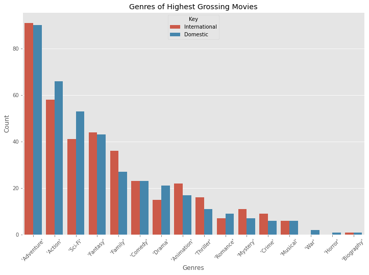

```python
df3=pd.DataFrame({'x':sorted_word_dictionary.keys(), 'y': sorted_word_dictionary.values()})
df4=pd.DataFrame({'x':sorted_word_dictionary2.keys(), 'y': sorted_word_dictionary2.values()})


df3['Key']='International'
df4['Key']='Domestic'
res=pd.concat([df3,df4])
sns.barplot(x='x',y='y',data=res,hue='Key',order = df4['x']) # df3['x'] sorts decending red (intl), change to df4 to sort blue (domestic)
plt.xticks(rotation=45)
plt.xlabel("Genres")
plt.ylabel("Count")
plt.title("Genres of Highest Grossing Movies")
plt.show()
```

### From the chart, it appears as if 'Sci-Fri' might have the biggest difference between domestic and international sales, but below I will use code to determine the difference in both absolute terms and as a percentage.

```python
max_absolute_change = 0
max_percentage_change = 0

for i in word_set:
    #print(i)
    # Music is not in both of them, so I am ignoring it
    if (i == "'Music'"):
        continue
    #print(sorted_word_dictionary[i])
    #print(sorted_word_dictionary2[i])
    x = sorted_word_dictionary[i]
    y = sorted_word_dictionary2[i]
    max_value = max(x,y)
    min_value = min(x,y)
    change = max_value - min_value
    #print("absolute change is ",change)
    percent_increase = ((max_value - min_value)/min_value) * 100
    #print("Percent change for ", i, " is: " , round(percent_increase,2))
    #print("mac is ",max_absolute_change)
    if (change > max_absolute_change):
        max_absolute_change = change
        biggest_absolute_change = i
        biggest_absolute_change_value = max_absolute_change
    if (percent_increase > max_percentage_change):
        max_percentage_change = percent_increase
        biggest_percent_change = i
        biggest_percent_change_value = max_percentage_change

print("Largest absolute change is ",biggest_absolute_change," with a change of",biggest_absolute_change_value)
print("Largest percentage change is ",biggest_percent_change," with a change of", "{:.2f}".format(biggest_percent_change_value),"%.")
```

```
Largest absolute change is  'Sci-Fi'  with a change of 12
Largest percentage change is  'Mystery'  with a change of 57.14 %.
```

### Here we see that of the top 100 highest grossing films, only 3 of them won the Oscar for Best Picture

```python
filt3 = top_domestic['Title'].isin(the_titles_list)
df1_best_picture_gross = top_domestic.loc[filt3,]
df1_best_picture_gross.shape
```

```
(3, 7)
```

```python
df1_best_picture_gross
```

|  | Title | Release Year | Domestic Sales (in $) | International Sales (in $) | Genre | Movie Runtime | License |
| --- | --- | --- | --- | --- | --- | --- | --- |
| 6 | Titanic | 1997 | 659363944 | 1542283320 | ['Drama', 'Romance'] | 194 | PG-13 |
| 45 | The Lord of the Rings: The Return of the King | 2003 | 377845905 | 768185007 | ['Action', 'Adventure', 'Drama', 'Fantasy'] | 201 | PG-13 |
| 67 | Forrest Gump | 1994 | 330455270 | 347770863 | ['Drama', 'Romance'] | 142 | PG-13 |

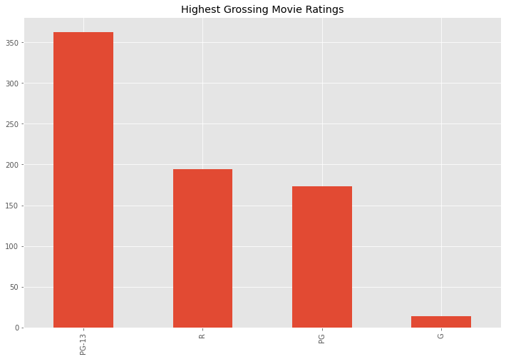

```python
df1['License'].value_counts().plot.bar(title="Highest Grossing Movie Ratings")
```

```python
df1['License'].value_counts()
```

```
PG-13    363
R        194
PG       173
G         14
Name: License, dtype: int64
```

```python
df1['License'].value_counts(normalize=True)
```

```
PG-13   0.49
R       0.26
PG      0.23
G       0.02
Name: License, dtype: float64
```

# Conclusion